# Analyse des ventes du site internet

*Importation des exports transmis par Laurent et Sylvie*

```r
setwd("~/Data")
erp <- read.csv2("erp.csv")
liaison <- read.csv2("liaison.csv")
web <- read.csv2("web.csv")
```

#### Rapprochement des exports erp et web

Commençons par tester l’unicité de notre clé (“product_id”) avant de merger nos exports erp et liaison.

```r
sum(duplicated(erp$product_id))
```

```
## [1] 0
```

```r
sum(duplicated(liaison$product_id))
```

```
## [1] 0
```

Vérifions également si nous avons bien les mêmes product_id dans erp et liaison :

```r
product_id1 <- unique(erp$product_id)
product_id2 <- unique(liaison$product_id)
product_id3 <- intersect(product_id2, product_id1)
```

Nous n’avons aucun doublon et nous avons bien les mêmes product_id dans erp et liaison donc poursuivons avec la jointure :

```r
erp_li <- merge(erp,liaison)
```

*Nous avons opté pour une jointure interne dans la mesure où ces 2 exports ont la même structure et le même nombre de lignes.*

Créons une copie de “web”.

```r
web2 <- web
```

Interrogeons la base pour obtenir les noms des colonnes du dataframe.

```r
names(web2)
```

```
##  [1] "sku"                   "virtual"               "downloadable"
##  [4] "rating_count"          "average_rating"        "total_sales"
##  [7] "tax_status"            "tax_class"             "post_author"
## [10] "post_date"             "post_date_gmt"         "post_content"
## [13] "post_title"            "post_excerpt"          "post_status"
## [16] "comment_status"        "ping_status"           "post_password"
## [19] "post_name"             "post_modified"         "post_modified_gmt"
## [22] "post_content_filtered" "post_parent"           "guid"
## [25] "menu_order"            "post_type"             "post_mime_type"
## [28] "comment_count"
```

Pour faciliter la jointure, nous renommons la colonne “sku” afin de la faire correspondre à la colonne “id_web”.

```r
names(web2)[names(web2) == 'sku'] <- 'id_web'
```

*Vérifions si le nom a bien été modifié :*

```r
names(web2)
```

```
##  [1] "id_web"                "virtual"               "downloadable"
##  [4] "rating_count"          "average_rating"        "total_sales"
##  [7] "tax_status"            "tax_class"             "post_author"
## [10] "post_date"             "post_date_gmt"         "post_content"
## [13] "post_title"            "post_excerpt"          "post_status"
## [16] "comment_status"        "ping_status"           "post_password"
## [19] "post_name"             "post_modified"         "post_modified_gmt"
## [22] "post_content_filtered" "post_parent"           "guid"
## [25] "menu_order"            "post_type"             "post_mime_type"
## [28] "comment_count"
```

*Tout est ok.*

Sélectionnons les lignes qui correspondent aux produits.

```r
web2 <- subset(web2, web2$post_type == "product")
```

Assurons-nous de ne pas avoir de doublon au niveau des id_web de web2 :

```r
sum(duplicated(web2$id_web))
```

```
## [1] 1
```

*Nous avons apparemment un doublon, que nous allons localiser et supprimer :*

```r
doublon <- which(duplicated(web2$id_web))
web2 <- web2[-doublon,]
```

Vérifions également si il existe des id_web dans erp_li qui ne sont pas dans web2 :

```r
id_web1 <- unique(erp_li$id_web)
id_web2 <- unique(web2$id_web)
id_web3 <- intersect(id_web2, id_web1)
```

*Il y a 20 id_web qui sont présents dans erp_li mais pas dans web2.*

Sélectionnons maintenant dans web2 les id_web présents dans id_web3 (*donc les éléments communs à erp_li et web2*).

```r
web2 <- web2[is.element (web2$id_web, id_web3),]
```

Nous pouvons maintenant joindre nos dataframes erp_li et web2.

```r
web_erp_li <- merge(erp_li, web2[(web2$id_web != ""),], all=T)
```

*Nous avons spécifié que nous ne voulions prendre que les lignes de web2 contenant un id_web.*

#### Calcul du chiffre d’affaires par produit

Supprimons une nouvelle fois les lignes n’ayant pas d’id_web

```r
web_erp_libis <- web_erp_li[web_erp_li$id_web != "",]
```

Vérifions maintenant si nous avons des doublons au niveau des product_id :

```r
sum(duplicated(web_erp_libis$product_id))
```

```
## [1] 0
```

*Aucun doublon ✓*

Sélectionnons puis extrayons toutes les lignes sans post_type :

```r
na <- which(is.na(web_erp_libis$post_type))
web_erp_libis <- web_erp_libis[-na,]
```

Vérifions la structure du dataframe obtenu :

```r
str(web_erp_libis)
```

```
## 'data.frame':    714 obs. of  33 variables:
##  $ id_web               : chr  "10014" "10459" "10775" "10814" ...
##  $ product_id           : int  5913 4617 4709 4656 4619 4970 5760 5801 4391 4364 ...
##  $ onsale_web           : int  1 1 1 1 1 1 1 1 1 1 ...
##  $ price                : num  36 67.5 44 43 59 49.5 13.1 24 49.5 49.5 ...
##  $ stock_quantity       : int  9 1 0 3 5 0 37 62 7 6 ...
##  $ stock_status         : chr  "instock" "instock" "outofstock" "instock" ...
##  $ virtual              : int  0 0 0 0 0 0 0 0 0 0 ...
##  $ downloadable         : int  0 0 0 0 0 0 0 0 0 0 ...
##  $ rating_count         : int  0 0 0 0 0 0 0 0 0 0 ...
##  $ average_rating       : int  0 0 0 0 0 0 0 0 0 0 ...
##  $ total_sales          : int  0 0 0 0 0 0 2 0 0 1 ...
##  $ tax_status           : chr  "taxable" "taxable" "taxable" "taxable" ...
##  $ tax_class            : logi  NA NA NA NA NA NA ...
##  $ post_author          : int  2 2 2 2 2 2 2 2 2 2 ...
```

[output cut: 19 more lines]

Calculons le CA généré par produit

```r
chiffre_affaires <- web_erp_libis$price * web_erp_libis$total_sales
```

*Les résultats sont stockés dans une liste.*

Joignons la liste de valeurs que nous avons obtenue à notre dataframe global :

```r
web_erp_libis <- data.frame(web_erp_libis, chiffre_affaires)
```

#### Calcul du CA total

Vérifions pour commencer la structure de la liste chiffre_affaires que nous venons de créer :

```r
str(chiffre_affaires)
```

```
##  num [1:714] 0 0 0 0 0 0 26.2 0 0 49.5 ...
```

*Nous avons bien des données de type numérique ✓*

Vérifions maintenant si nous avons des données manquantes :

```r
is.na(web_erp_libis$chiffre_affaires)
```

```
##   [1] FALSE FALSE FALSE FALSE FALSE FALSE FALSE FALSE FALSE FALSE FALSE FALSE
##  [13] FALSE FALSE FALSE FALSE FALSE FALSE FALSE FALSE FALSE FALSE FALSE FALSE
##  [25] FALSE FALSE FALSE FALSE FALSE FALSE FALSE FALSE FALSE FALSE FALSE FALSE
##  [37] FALSE FALSE FALSE FALSE FALSE FALSE FALSE FALSE FALSE FALSE FALSE FALSE
##  [49] FALSE FALSE FALSE FALSE FALSE FALSE FALSE FALSE FALSE FALSE FALSE FALSE
##  [61] FALSE FALSE FALSE FALSE FALSE FALSE FALSE FALSE FALSE FALSE FALSE FALSE
##  [73] FALSE FALSE FALSE FALSE FALSE FALSE FALSE FALSE FALSE FALSE FALSE FALSE
##  [85] FALSE FALSE FALSE FALSE FALSE FALSE FALSE FALSE FALSE FALSE FALSE FALSE
##  [97] FALSE FALSE FALSE FALSE FALSE FALSE FALSE FALSE FALSE FALSE FALSE FALSE
## [109] FALSE FALSE FALSE FALSE FALSE FALSE FALSE FALSE FALSE FALSE FALSE FALSE
## [121] FALSE FALSE FALSE FALSE FALSE FALSE FALSE FALSE FALSE FALSE FALSE FALSE
## [133] FALSE FALSE FALSE FALSE FALSE FALSE FALSE FALSE FALSE FALSE FALSE FALSE
## [145] FALSE FALSE FALSE FALSE FALSE FALSE FALSE FALSE FALSE FALSE FALSE FALSE
## [157] FALSE FALSE FALSE FALSE FALSE FALSE FALSE FALSE FALSE FALSE FALSE FALSE
## [169] FALSE FALSE FALSE FALSE FALSE FALSE FALSE FALSE FALSE FALSE FALSE FALSE
```

[output cut: 45 more lines]

```r
na2 <- which(is.na(web_erp_li$chiffre_affaires))
```

*Pas de données manquantes ✓*

Additionnons le tout :

```r
ca_total <- sum(web_erp_libis$chiffre_affaires)
```

*Ce qui nous donne un CA global de …*

```r
ca_total
```

```
## [1] 70568.6
```

#### Détection des éventuelles valeurs aberrantes

Jetons un oeil aux statistiques relatives aux prix et aux ventes :

```r
summary(web_erp_libis$price)
```

```
##    Min. 1st Qu.  Median    Mean 3rd Qu.    Max.
##    5.20   14.10   23.55   32.49   42.17  225.00
```

```r
summary(web_erp_libis$total_sales)
```

```
##    Min. 1st Qu.  Median    Mean 3rd Qu.    Max.
##   0.000   0.000   1.000   4.013   4.000  96.000
```

Calculons Q3-Q1 (écart interquartile) :

```r
IQR(web_erp_libis$price)
```

```
## [1] 28.075
```

Multiplions le maintenant par 1.5 :

```r
1.5*IQR(web_erp_libis$price)
```

```
## [1] 42.1125
```

Voyons si nous avons des valeurs aberrantes :

```r
boxplot.stats(web_erp_libis$price)$out
```

```
##  [1]  99.0 105.0  88.4 126.5 115.0 105.0 109.6  85.6  86.8 112.0 115.0 137.0
## [13] 217.5 105.6 114.0  93.0 122.0 102.3 124.8 135.0 191.3 121.0 121.0 116.4
## [25] 175.0 100.0 225.0  92.0 108.5 104.0 176.0 157.0
```

*Lesdites valeurs aberrantes (sont considérées comme aberrantes toutes les valeurs supérieures ou égales à 84.2825 soit Q3+1.5*IQR)*

La position des valeurs aberrantes :

```r
which(web_erp_libis$price %in% boxplot.stats(web_erp_libis$price)$out)
```

```
##  [1]  13  14  16  39  46  47  48 104 110 111 118 132 162 163 187 188 189 193 209
## [20] 210 222 233 234 243 264 320 512 676 683 684 685 698
```

*Représentons les graphiquement pour une meilleure compréhension en utilisant un diagramme en boîte à moustache :*

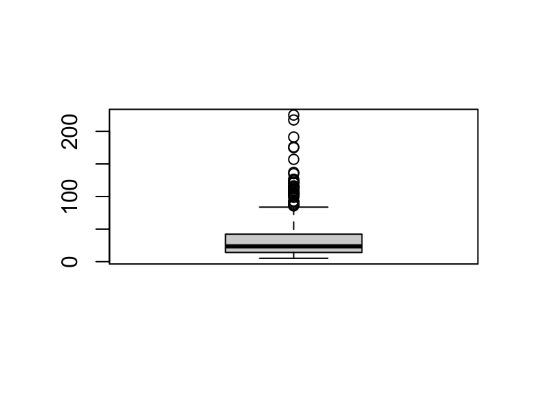

```r
boxplot(web_erp_libis$price)
```

*Représentons également les ventes sous forme de grapghique en nuage de points :*

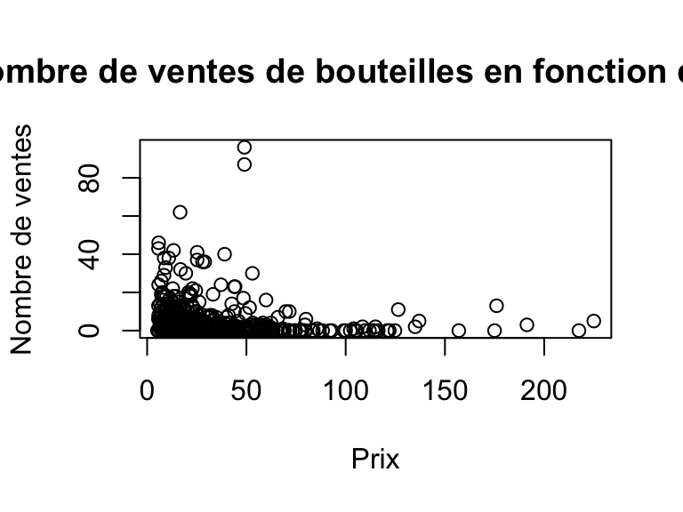

```r
plot(x = web_erp_libis$price, y = web_erp_libis$total_sales, xlab = "Prix", ylab = "Nombre de ventes", xlim = c(5.20, 225.00), ylim = c(0, 96.000), main = "Nombre de ventes de bouteilles en fonction du prix")
```